# What made you happy today?

# Introduction

It has become increasingly important for us to know what makes us happy due to the fast-paced lifestyle nowadays.And aftering some analyse on the 100000 happy moments,I am going to tell a story about happpiness and show the base of my story.

## First step: importing and merging data

```r
clean = read.csv("./data/cleaned_hm.csv",header = T)
demo = read.csv("./data/demographic.csv",header = T)
combine = merge (clean,demo,by="wid",all=F)
```

There are serval stages in our life: when we are juveniles, becoming adults,getting married, with baby born,we become parents and so on. We have different identites and thus duties in different stages, therefore, reasons that why we are happy may show up differently. However, there are still something always make us happy.

## Second step: spliting data

```r
table(demo$country)
```

```
##
##       AFG  ALB  ARE  ARG  ARM  ASM  AUS  AUT  BEL  BGD  BGR  BHS  BRA  BRB
##   73    3    4    6    2    1    3   14    3    4    2    3    1   14    2
##  CAN  CHL  COL  CRI  CYP  CZE  DEU  DNK  DOM  DZA  ECU  EGY  ESP  EST  ETH
##   66    2    6    1    1    2    8    1    2    3    1    5    6    2    1
##  FIN  FRA  GBR  GHA  GMB  GRC  GTM  HKG  HRV  IDN  IND  IRL  IRQ  ISL  ISR
##    5   10   48    1    1    9    2    1    2    6  964    3    1    2    1
##  ITA  JAM  JPN  KAZ  KEN  KNA  KOR  KWT  LKA  LTU  LVA  MAC  MAR  MDA  MEX
##   11    7    2    1    2    1    1    1    2    6    1    1    2    2   22
##  MKD  MLT  MUS  MYS  NGA  NIC  NLD  NOR  NPL  NZL  PAK  PER  PHL  POL  PRI
##    5    2    1    5   12    2    3    1    2    8    5    2   32    4    2
##  PRT  ROU  RUS  SAU  SGP  SLV  SRB  SUR  SVN  SWE  TCA  THA  TTO  TUN  TUR
##    8    5    1    1    6    1    6    1    1    1    2    3    3    1    8
##  TWN  UGA  UKR  UMI  URY  USA  VEN  VIR  VNM  ZAF  ZMB
##    1    4    1    4    1 9274   54    1    2    7    1
```

```r
table(demo$gender)
```

```
##
##         f    m    o
##   32 5445 5311   56
```

```r
table(demo$marital)
```

```
##
##            divorced   married separated    single   widowed
##        57       565      4371       102      5678        71
```

```r
table(demo$parenthood)
```

```
##
##         n    y
##   31 6448 4365
```

Above are four differents ways to classify people we have recorded. On the first way, we found that most people in the data come from ths USA and IND, thus we need to split these two type of people out from the original data.

```r
ll <- split(combine,combine$country)
USA <- ll$USA
IND <- ll$IND
```

Then, let us see the difference between these two types of people.

```r
rate <- function(name){
  return(table(name)/length(name))
}
rate(USA$predicted_category)
```

```
## name
##      achievement        affection          bonding enjoy_the_moment
##       0.35335113       0.33227932       0.09949028       0.10912816
##         exercise          leisure           nature
##       0.01324260       0.07210705       0.02040145
```

```r
rate(IND$predicted_category)
```

```
## name
##      achievement        affection          bonding enjoy_the_moment
##      0.257038675      0.388188176      0.139637755      0.115846733
##         exercise          leisure           nature
##      0.006216749      0.084224999      0.008846913
```

First of all, achivement and affection are two main reasons that make people happy for both of these countries. But,people from USA are more likely to be happy because of achievement compared to people from IND. USA is a developed country, and IND is a developing country, therefore, it is likely that better the economy, greater chance for people to chase their goal and enjoy it. What’ more, people from USA enjoy more on exercise than IND people do, this makes sense because there are so many world-famous sports leage, such as NBA in USA. This also based on good economy. In a word, with the economy developed, people’s happyiness foucus will transit from affection to achievement. My further anaylse would base on people from the USA.

## Third step: defining life’s stage

The first stage is juvenile, which means age under 18. The following stage would be life before marry. We need to find out the average age that people from the data get married. Usually, male get married later than female do, and there are many other difference between male and female, thus, we need to seperate people according to their gender.

```r
gender <- split(USA,USA$gender)
male <- gender$m
female <- gender$f
rate(male$predicted_category)
```

```
## name
##      achievement        affection          bonding enjoy_the_moment
##       0.38304074       0.27994306       0.10257801       0.11787433
##         exercise          leisure           nature
##       0.01604193       0.08303396       0.01748797
```

```r
rate(female$predicted_category)
```

```
## name
##      achievement        affection          bonding enjoy_the_moment
##      0.314692082      0.401114370      0.094956012      0.097448680
##         exercise          leisure           nature
##      0.009589443      0.057947214      0.024252199
```

Clearly, female are much more likely to be happy due to affection than male do, this corresponds to the saying: male are rational and female are sensuous. This also could be explained on the foot of economy: male are richer than female on average. Next, let us find out the averaged marry age for male and female.

```r
table(male$marital)
```

```
##
##            divorced   married separated    single   widowed
##        37      1367     14561       101     28088       105
```

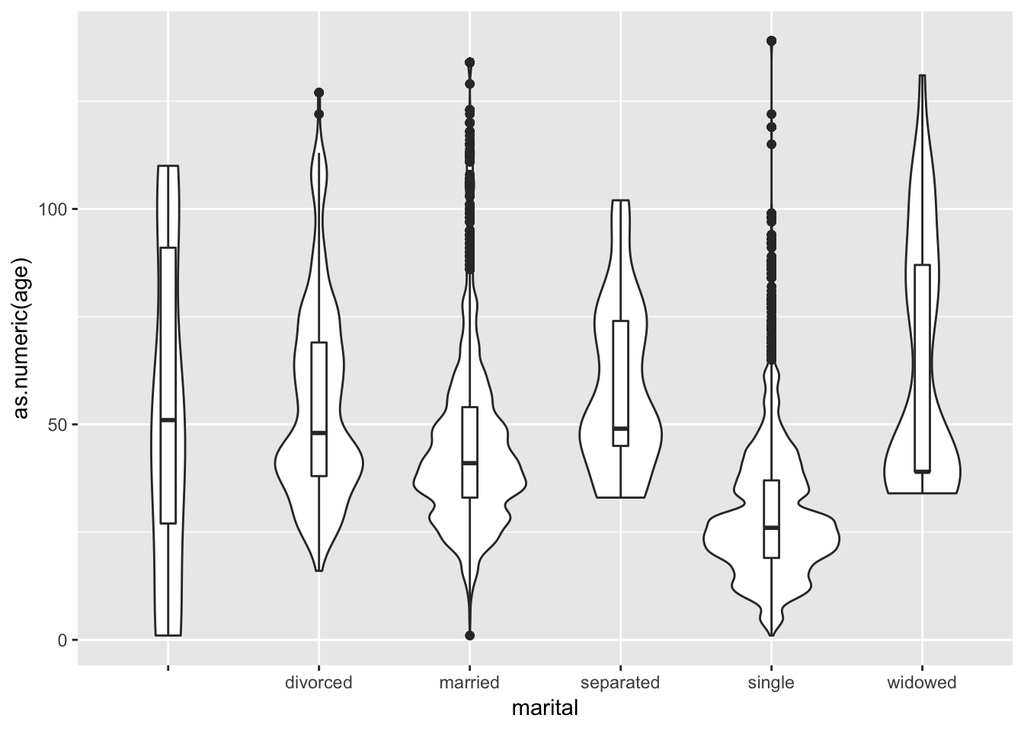

```r
library(ggplot2)
ggplot(male,aes(x=marital,y=as.numeric(age)))+geom_violin()+geom_boxplot(width=0.1)
```

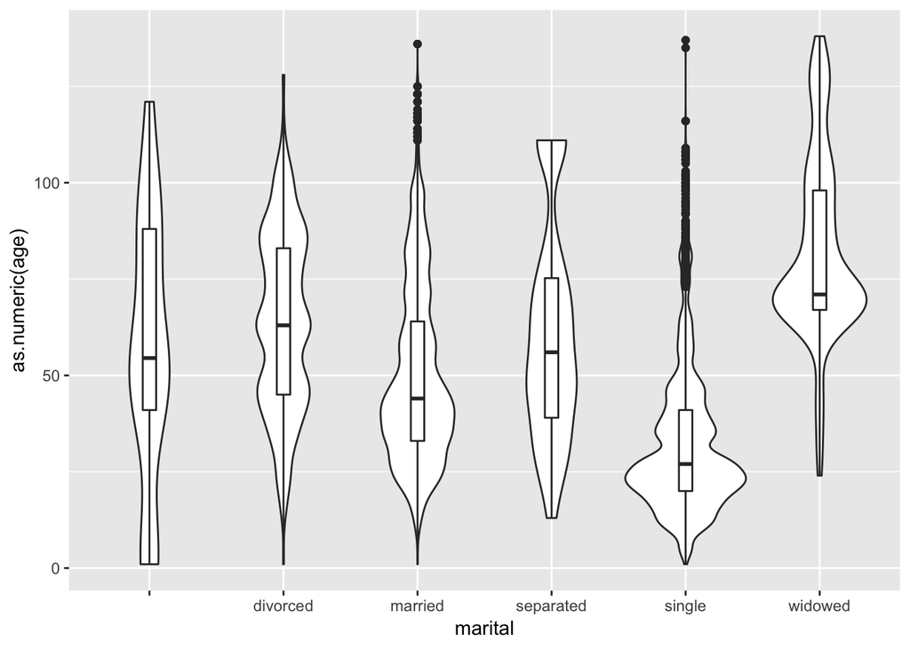

```r
ggplot(female,aes(x=marital,y=as.numeric(age)))+geom_violin()+geom_boxplot(width=0.1)
```

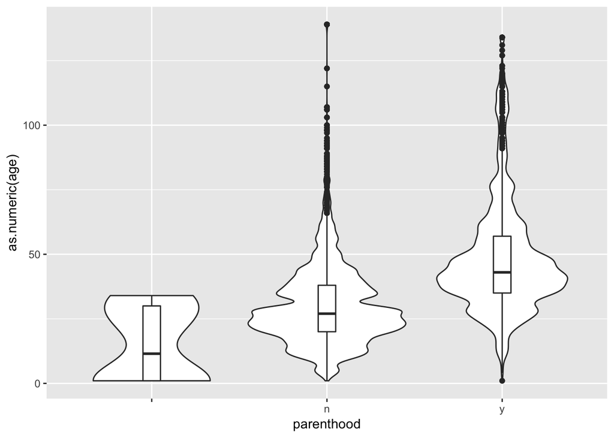

```r
ggplot(male,aes(x=parenthood,y=as.numeric(age)))+geom_violin()+geom_boxplot(width=0.1)
```

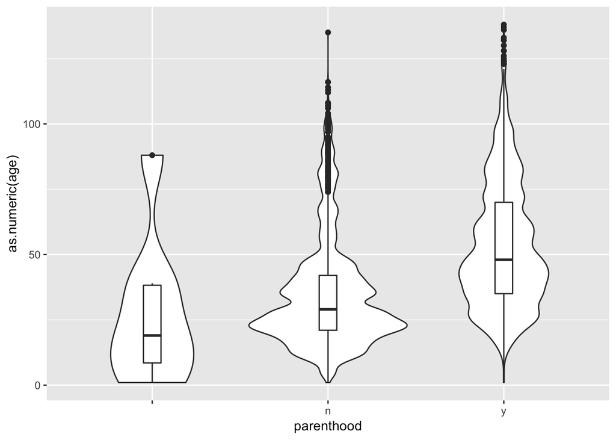

```r
ggplot(female,aes(x=parenthood,y=as.numeric(age)))+geom_violin()+geom_boxplot(width=0.1)
```

The age for both male and female to become parents are almost the same as that to ger married. Thus, we need to combine the second and the third stage together. According to the USA law, both male and female are retire at the age of 65, thus, age over 65 would be the last stage. However, the third stage would last too long, so,dividing the third stage into two part: age before 40 and age after 40. There are totally 5 stages in the end.

### Male

```r
mstage1 <- male$predicted_category[which(as.numeric(male$age)<18)]
mstage2 <- male$predicted_category[which(as.numeric(male$age)<24&as.numeric(male$age)>17)]
mstage3 <- male$predicted_category[which(as.numeric(male$age)<40&as.numeric(male$age)>23)]
mstage4 <- male$predicted_category[which(as.numeric(male$age)<65&as.numeric(male$age)>39)]
mstage5 <- male$predicted_category[which(as.numeric(male$age)>64)]
ms1 <- rate(mstage1)
ms2 <- rate(mstage2)
ms3 <- rate(mstage3)
ms4 <- rate(mstage4)
ms5 <- rate(mstage5)
stage <- c(1,2,3,4,5,1,2,3,4,5)
machievement <- c(ms1[1],ms2[1],ms3[1],ms4[1],ms5[1])
maffection <- c(ms1[2],ms2[2],ms3[2],ms4[2],ms4[2])
```

### Female

```r
fstage1 <- female$predicted_category[which(as.numeric(male$age)<18)]
fstage2 <- female$predicted_category[which(as.numeric(male$age)<26&as.numeric(male$age)>17)]
fstage3 <- female$predicted_category[which(as.numeric(male$age)<40&as.numeric(male$age)>25)]
fstage4 <- female$predicted_category[which(as.numeric(male$age)<65&as.numeric(male$age)>39)]
fstage5 <- female$predicted_category[which(as.numeric(male$age)>64)]
fs1 <- rate(fstage1)
fs2 <- rate(fstage2)
fs3 <- rate(fstage3)
fs4 <- rate(fstage4)
fs5 <- rate(fstage5)
fachievement <- c(fs1[1],fs2[1],fs3[1],fs4[1],fs5[1])
faffection <- c(fs1[2],fs2[2],fs3[2],fs4[2],fs5[2])
sex=c(rep("m",5),rep("f",5))
```

## Step forth: Graphic analyse

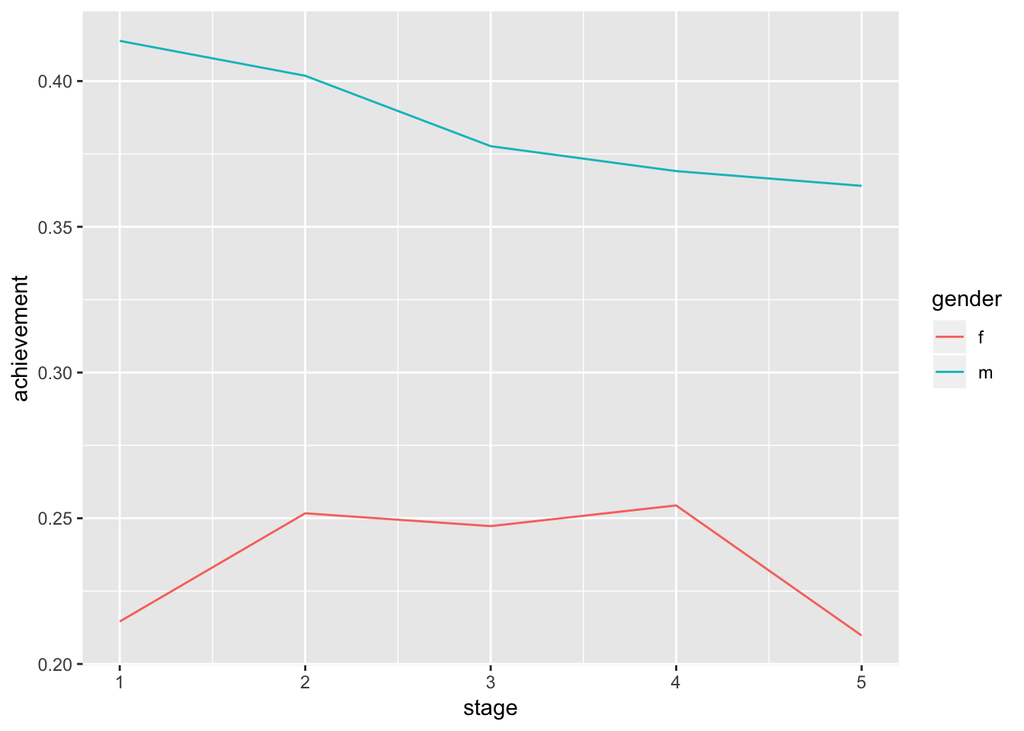

```r
mf <- data.frame(stage=stage,achievement=c(machievement,fachievement),affection=c(maffection,faf=faffection),gender=as.factor(sex))
p <- ggplot(mf)+geom_line(mapping = aes(x=stage,y=achievement,colour=gender))
print(p)
```

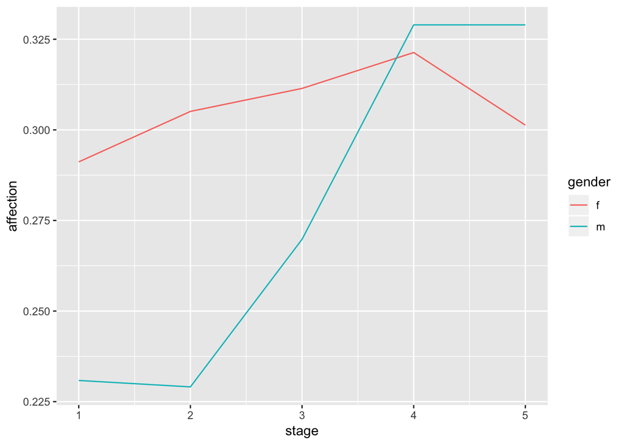

```r
q <- ggplot(mf)+geom_line(mapping = aes(x=stage,y=affection,colour=gender))
print(q)
```

## Step fifth: Conclusion

```r
library(tm)
```

```r
library(SnowballC)
library(tidytext)
library(wordcloud)
library(RColorBrewer)
library(RColorBrewer)
library(dplyr)
```

### Word Frequency

```r
senselabel = read.csv("./data/senselabel.csv")
sen = senselabel %>% group_by(hmid) %>% summarise(sent = paste(lowercaseLemma, collapse = ' ')) %>% as.data.frame()
data = merge(clean, sen, by.x = "hmid", by.y = "hmid")
pre = split(data,data$predicted_category)
```

```r
prepro = function(data) {
  corpus = VCorpus(VectorSource(data$sent))
  corpus = tm_map(corpus, removePunctuation)
  corpus = tm_map(corpus, removeWords, stopwords())
  ttt = TermDocumentMatrix(corpus)
  ttt.tidy = tidy(ttt)
  ttt.overall = summarise(group_by(ttt.tidy, term), sum(count))
  return(ttt.overall)
}
```

### Key words in achievement, from the plot we know that new thing, work and get something easily make people happy.

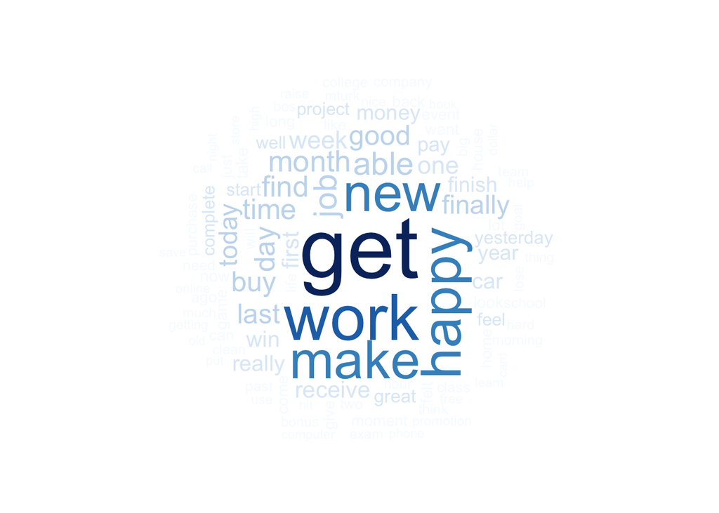

```r
ttt.overall = prepro(pre$achievement)
wordcloud(ttt.overall$term, ttt.overall$`sum(count)`,
          scale=c(5,0.5), max.words=100,
          min.freq=1, random.order=FALSE,
          rot.per=0.3, use.r.layout=T,
          random.color=FALSE, colors=brewer.pal(9,"Blues"))
```

### As for affection, key words focous more on our families and friends.

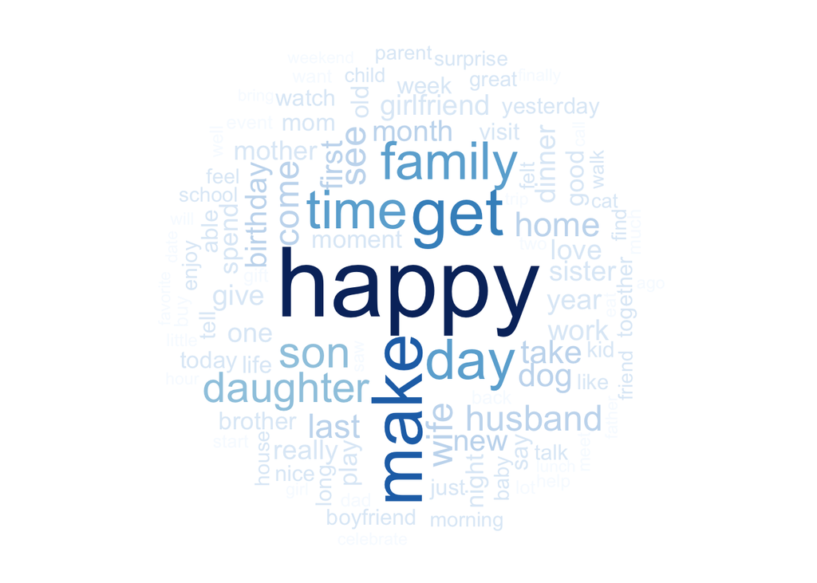

```r
ttt.overall = prepro(pre$affection)
wordcloud(ttt.overall$term, ttt.overall$`sum(count)`,
          scale=c(5,0.5), max.words=100,
          min.freq=1, random.order=FALSE,
          rot.per=0.3, use.r.layout=T,
          random.color=FALSE, colors=brewer.pal(9,"Blues"))
```

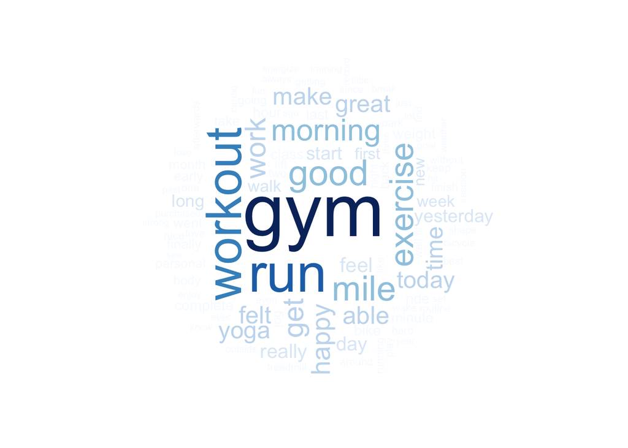

```r
ttt.overall = prepro(pre$exercise)
wordcloud(ttt.overall$term, ttt.overall$`sum(count)`,
          scale=c(5,0.5), max.words=100,
          min.freq=1, random.order=FALSE,
          rot.per=0.3, use.r.layout=T,
          random.color=FALSE, colors=brewer.pal(9,"Blues"))
```

```r
corpus = VCorpus(VectorSource(pre))
corpus = tm_map(corpus, removePunctuation)
corpus = tm_map(corpus, removeWords, stopwords())
```

```r
dtm = DocumentTermMatrix(corpus,
                          control = list(weighting = function(x)
                                             weightTfIdf(x,
                                                         normalize =FALSE),
                                         stopwords = TRUE))
ff.dtm = tidy(dtm)
ff.dtm$document[ff.dtm$document == 1] = "achievement"
ff.dtm$document[ff.dtm$document == 2] = "affection"
ff.dtm$document[ff.dtm$document == 3] = "bonding"
ff.dtm$document[ff.dtm$document == 4] = "enjoy_the_moment"
ff.dtm$document[ff.dtm$document == 5] = "exercise"
ff.dtm$document[ff.dtm$document == 6] = "leisure"
ff.dtm$document[ff.dtm$document == 7] = "nature"
```

```r
emtions = c("achievement", "affection", "bonding", "enjoy_the_moment", "exercise", "leisure", "nature")
library(shiny)
shinyApp(
    ui = fluidPage(
      fluidRow(style = "padding-bottom: 20px;",
        column(4, selectInput('speech1', 'Emotion 1', emtions,
                              selected = emtions[1])),
        column(4, selectInput('speech2', 'Emotion 2', emtions,
                              selected = emtions[2])),
        column(4, sliderInput('nwords', 'Number of words', 3,
                               min = 20, max = 200, value=100, step = 20))
      ),
      fluidRow(
        plotOutput('wordclouds', height = "400px")
      )
    ),
    server = function(input, output, session) {
      # Combine the selected variables into a new data frame
      selectedData <- reactive({
        list(dtm.term1=ff.dtm$term[ff.dtm$document == input$speech1],
             dtm.count1=ff.dtm$count[ff.dtm$document == input$speech1],
             dtm.term2=ff.dtm$term[ff.dtm$document == input$speech2],
             dtm.count2=ff.dtm$count[ff.dtm$document == input$speech2])
      })
      output$wordclouds <- renderPlot(height = 400, {
        par(mfrow=c(1,2), mar = c(0, 0, 3, 0))
        wordcloud(selectedData()$dtm.term1,
                  selectedData()$dtm.count1,
              scale = c(5,0.5),
              max.words=input$nwords, min.freq = 3,
              random.order=FALSE, rot.per=0.3,
              use.r.layout=FALSE, random.color=FALSE,
              colors=brewer.pal(9, "Blues"),
            main=input$speech1)
        wordcloud(selectedData()$dtm.term2,
                  selectedData()$dtm.count2,
              scale=c(5,0.5),
              max.words = input$nwords,
              min.freq = 3, random.order = FALSE,
              rot.per = 0.3, use.r.layout = FALSE,
              random.color = FALSE,
              colors=brewer.pal(9, "Blues"),
            main=input$speech2)
      })
    },
    options = list(height = 500)
)
```

Shiny applications not supported in static R Markdown documents

### Topic Words

```r
entertainment = read.csv("./data/topic_dict/entertainment-dict.csv", header = FALSE); entertainment = as.character(entertainment$V1)
exercise = read.csv("./data/topic_dict/exercise-dict.csv", header = FALSE); exercise = as.character(exercise$V1)
family = read.csv("./data/topic_dict/family-dict.csv", header = FALSE); family = as.character(family$V1)
food = read.csv("./data/topic_dict/food-dict.csv", header = FALSE); food = as.character(food$V1)
people = read.csv("./data/topic_dict/people-dict.csv", header = FALSE); people = as.character(people$V1)
pets = read.csv("./data/topic_dict/pets-dict.csv", header = FALSE); pets = as.character(pets$V1)
school = read.csv("./data/topic_dict/school-dict.csv", header = FALSE); school = as.character(school$V1)
shopping = read.csv("./data/topic_dict/shopping-dict.csv", header = FALSE); shopping = as.character(shopping$V1)
work = read.csv("./data/topic_dict/work-dict.csv", header = FALSE); work = as.character(work$V1)
```

```r
topic_cnt = lapply(
  strsplit(data$sent, " "), function(x){
    c(sum(x %in% entertainment), sum(x %in% exercise),sum(x %in% family), sum(x %in% food),
      sum(x %in% people), sum(x %in% pets),sum(x %in% school), sum(x %in% shopping),sum(x %in% work))})
topic_cnt = as.data.frame(matrix(unlist(topic_cnt), ncol = 9, byrow = TRUE),
                          col.names = c("entertainment", "exercise", "family", "food", "people",
                                        "pets", "school", "shopping", "work"))
data_topic = merge(data[, c("sent", "predicted_category")], topic_cnt, by.x = 0, by.y = 0)
temp = c("V1", "V2", "V3", "V4", "V5", "V6", "V7", "V8", "V9")
topic = data.frame(
  rbind(apply(data_topic[data_topic$predicted_category == "achievement", temp], 2, sum),
        apply(data_topic[data_topic$predicted_category == "affection", temp], 2, sum),
        apply(data_topic[data_topic$predicted_category == "bonding", temp], 2, sum),
        apply(data_topic[data_topic$predicted_category == "enjoy_the_moment", temp], 2, sum),
        apply(data_topic[data_topic$predicted_category == "exercise", temp], 2, sum),
        apply(data_topic[data_topic$predicted_category == "leisure", temp], 2, sum),
        apply(data_topic[data_topic$predicted_category == "nature", temp], 2, sum)), row.names = emtions)
colnames(topic) = c("entertainment", "exercise", "family", "food", "people", "pets", "school", "shopping", "work")
```

```r
myhc_add_series_labels_values = function (hc, labels, values, text, colors = NULL, ...)
{
    assertthat::assert_that(is.highchart(hc), is.numeric(values),
        length(labels) == length(values))
    df <- dplyr::data_frame(name = labels, y = values, text=text)
    if (!is.null(colors)) {
        assert_that(length(labels) == length(colors))
        df <- mutate(df, color = colors)
    }
    ds <- list_parse(df)
    hc <- hc %>% hc_add_series(data = ds, ...)
    hc
}
```

## Using the files in topic-word folder, we can caculate how many different topics are used for different emotions. From the pie plot we can roughly find the relationship between emotions and topics, including work, entertainment, family and so on.

```r
library(highcharter)
A = colnames(topic)
B = as.numeric(topic["achievement",])
C = as.numeric(topic["achievement",])
df = data.frame(A, B, C)

highchart() %>%
  hc_chart(type = "pie", data=df) %>%
  myhc_add_series_labels_values(labels=A, values=B, text=C) %>%
  hc_tooltip(crosshairs=TRUE, borderWidth=5, sort=TRUE, shared=TRUE, table=TRUE,
     pointFormat=paste('<br><b>A: {point.percentage:.1f}%</b><br>C: {point.text}')) %>%
  hc_title(text="Pie Plot of Topic Words for Achievement", margin=20, style=list(color="#144746", useHTML=TRUE))
```

[interactive chart not shown]

```r
A = colnames(topic)
B = as.numeric(topic["affection",])
C = as.numeric(topic["affection",])
df = data.frame(A, B, C)

highchart() %>%
  hc_chart(type = "pie", data = df) %>%
  myhc_add_series_labels_values(labels=A, values=B, text=C) %>%
  hc_tooltip(crosshairs=TRUE, borderWidth=5, sort=TRUE, shared=TRUE, table=TRUE,
     pointFormat=paste('<br><b>A: {point.percentage:.1f}%</b><br>C: {point.text}')) %>%
  hc_title(text="Pie Plot of Topic Words for Affection", margin=20, style=list(color="#144746", useHTML=TRUE))
```

[interactive chart not shown]